# Provide background for understanding the nature of subscription data over time etc.

March 19, 2018

Read prepared data from Jakubs prepared subscription file.

```r
library(tidyverse)
library(lubridate)
subscriptions <- read_rds('data/subscriptions.rds')
```

# Premium vs. Freemium

In 2015, we started on a new business model.

Before: Users would get a free 1 month subscription and would then have to either become paying subscribers or get their sites closed. Typically, they buy 3 or 12 months up front.

After: Users get a continued free subs, and can choose to convert. If they convert, their first paid subscription will be a 1 month subs purchased very cheaply, including a domain. Then we renew them on a 3 month plan (typically).

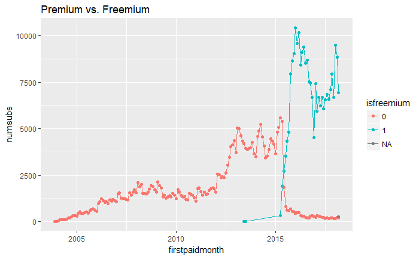

```r
tmp <- subscriptions %>%
  # Only firs subs
  dplyr::filter(num_previous_subs == 0) %>%
  dplyr::mutate(isfreemium = factor(isfreemium)) %>%
  dplyr::group_by(firstpaidmonth, isfreemium) %>%
  dplyr::summarise(numsubs = n()) %>%
  dplyr::ungroup()
tmp %>% ggplot(aes(x=firstpaidmonth, y=numsubs, color=isfreemium)) + geom_point() + geom_line() +
  ggtitle("Premium vs. Freemium")
```

We still have a little Premium left on the old “Sitevers” (.dk, .se, .fr, etc.) where new “organic”" users still come in to the old sites because they know of them. siteverkey = ‘US’ corresponds to SimpleSite.com and it is on that one that we do Freemium.

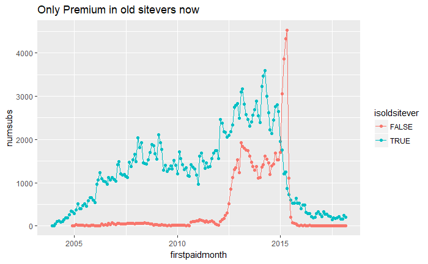

```r
tmp <- subscriptions %>%
  # Only firs subs
  dplyr::filter(num_previous_subs == 0) %>%
  # Only premium
  dplyr::filter(isfreemium == 0) %>%
  # is old sitever
  dplyr::mutate(isoldsitever = ifelse(siteverkey == 'US', F, T)) %>%
  dplyr::group_by(firstpaidmonth, isoldsitever) %>%
  dplyr::summarise(numsubs = n()) %>%
  dplyr::ungroup()
tmp %>% ggplot(aes(x=firstpaidmonth, y=numsubs, color=isoldsitever)) + geom_point() + geom_line() +
  ggtitle("Only Premium in old sitevers now")
```

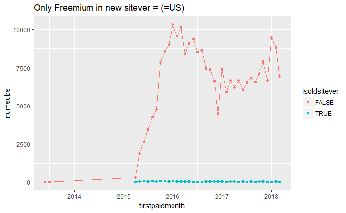

```r
tmp <- subscriptions %>%
  # Only first subs
  dplyr::filter(num_previous_subs == 0) %>%
  # Only premium
  dplyr::filter(isfreemium == 1) %>%
  # is old sitever
  dplyr::mutate(isoldsitever = ifelse(siteverkey == 'US', F, T)) %>%
  dplyr::group_by(firstpaidmonth, isoldsitever) %>%
  dplyr::summarise(numsubs = n()) %>%
  dplyr::ungroup()
tmp %>% ggplot(aes(x=firstpaidmonth, y=numsubs, color=isoldsitever)) + geom_point() + geom_line() +
  ggtitle("Only Freemium in new sitever = (=US)")
```

In the old sitevers, there has been a shift over time in what we have offered as a first subscription period and how we have pitched those options. At present, it is mostly 3 month periods that the users start with.

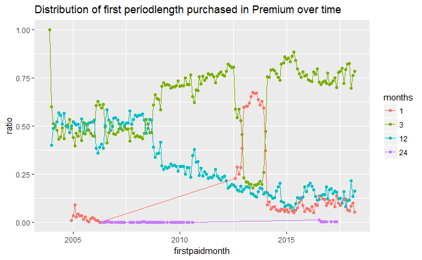

```r
tmp <- subscriptions %>%
  # Only first subs
  dplyr::filter(num_previous_subs == 0) %>%
  # Only premium
  dplyr::filter(isfreemium == 0) %>%
  dplyr::mutate(months = factor(months)) %>%
  dplyr::group_by(firstpaidmonth, months) %>%
  dplyr::summarise(numsubs = n()) %>%
  dplyr::group_by(firstpaidmonth) %>%
  dplyr::mutate(ratio = numsubs / sum(numsubs)) %>%
  dplyr::ungroup()
tmp %>% ggplot(aes(x=firstpaidmonth, y=ratio, color=months)) + geom_point() + geom_line() +
  ggtitle("Distribution of first periodlength purchased in Premium over time")
```

In the Freemium solution (sitever = US), when users buy the first 1-month subscription, they are also signed up for a continued subscription of a given periodlength. In some periods, it has been completely implicitly that it was just 3 months for all. In other periods, we we have experimented with offering a choice between 3, 12 and sometimes 24 months. Starting late 2015, there has been considerable experimentation on this, very often specialized to specific markets, currencies, etc.

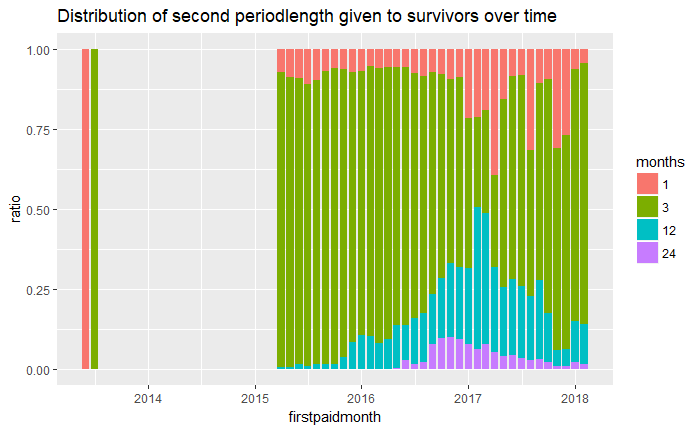

```r
tmp <- subscriptions %>%
  # Look at subs following first 1 month subs
  dplyr::filter(num_previous_subs == 1 & status != 'churn') %>%
  # Only freemium
  dplyr::filter(isfreemium == 1) %>%
  dplyr::mutate(months = factor(months)) %>%
  dplyr::group_by(firstpaidmonth, months) %>%
  dplyr::summarise(numsubs = n()) %>%
  dplyr::group_by(firstpaidmonth) %>%
  dplyr::mutate(ratio = numsubs / sum(numsubs)) %>%
  dplyr::ungroup()
tmp %>% ggplot(aes(x=firstpaidmonth, y=ratio, fill=months)) + geom_col() +
  ggtitle("Distribution of second periodlength given to survivors over time")
```

paymentperiodchosenatstart is what we sign users up for as renewal periodlength. It can happen that the actual subscription that they get is another one, if something manual happens before we bill the second subs. But it is rare that there is this change and most often periodlength = paymentperiodchosenatstart.

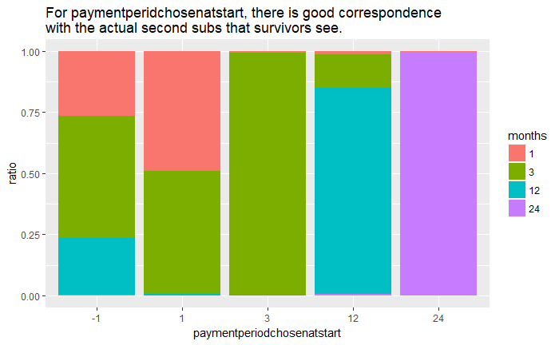

```r
tmp <- subscriptions %>%
  # Look at subs following first 1 month subs
  dplyr::filter(num_previous_subs == 1 & status != 'churn') %>%
  # Only freemium
  dplyr::filter(isfreemium == 1) %>%
  dplyr::mutate(paymentperiodchosenatstart = factor(paymentperiodchosenatstart)) %>%
  dplyr::mutate(months = factor(months)) %>%
  dplyr::group_by(months, paymentperiodchosenatstart) %>%
  dplyr::summarise(numsubs = n()) %>%
  dplyr::group_by(paymentperiodchosenatstart) %>%
  dplyr::mutate(ratio = numsubs / sum(numsubs)) %>%
  dplyr::ungroup()
tmp %>% ggplot(aes(x=paymentperiodchosenatstart, y=ratio, fill=months)) + geom_col() +
  ggtitle("For paymentperidchosenatstart, there is good correspondence \nwith the actual second subs that survivors see.")
```

A bunch of experiments and business models over time has explored how to approach 3, 12, or 24. They give quite different distributions.

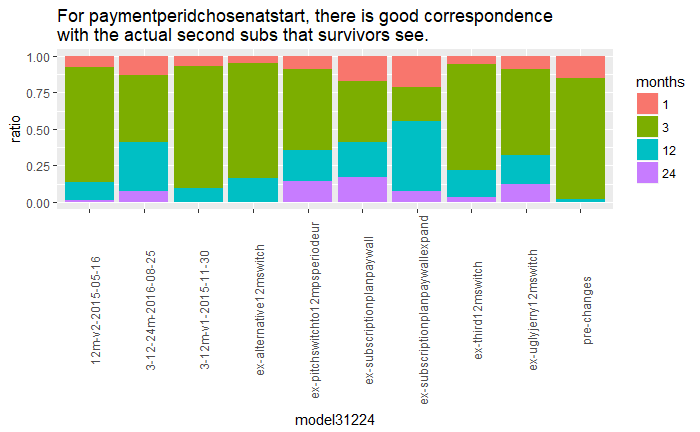

```r
tmp <- subscriptions %>%
  # Look at subs following first 1 month subs
  dplyr::filter(num_previous_subs == 1 & status != 'churn') %>%
  # Only freemium
  dplyr::filter(isfreemium == 1) %>%
  dplyr::mutate(months = factor(months)) %>%
  dplyr::group_by(months, model31224) %>%
  dplyr::summarise(numsubs = n()) %>%
  dplyr::group_by(model31224) %>%
  dplyr::mutate(ratio = numsubs / sum(numsubs)) %>%
  dplyr::ungroup()
tmp %>% ggplot(aes(x=model31224, y=ratio, fill=months)) + geom_col() +
  ggtitle("For paymentperidchosenatstart, there is good correspondence \nwith the actual second subs that survivors see.") +
  theme(axis.text.x = element_text(angle=90))
```

This illustrates how the different business models have been in play over time.

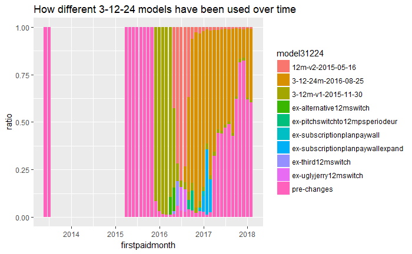

```r
tmp <- subscriptions %>%
  # Look at subs following first 1 month subs
  dplyr::filter(num_previous_subs == 1 & status != 'churn') %>%
  # Only freemium
  dplyr::filter(isfreemium == 1) %>%
  dplyr::group_by(firstpaidmonth, model31224) %>%
  dplyr::summarise(numsubs = n()) %>%
  dplyr::group_by(firstpaidmonth) %>%
  dplyr::mutate(ratio = numsubs / sum(numsubs)) %>%
  dplyr::ungroup()
tmp %>% ggplot(aes(x=firstpaidmonth, y=ratio, fill=model31224)) + geom_col() +
  ggtitle("How different 3-12-24 models have been used over time")
```

Here is it just for USD - now predominantly pre-changes i.e. almost only 3m subses.

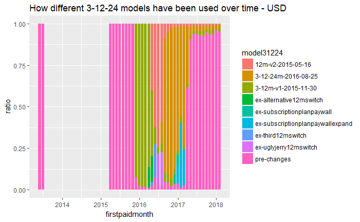

```r
tmp <- subscriptions %>%
  # Look at subs following first 1 month subs
  dplyr::filter(num_previous_subs == 1 & status != 'churn' & currency == "USD") %>%
  # Only freemium
  dplyr::filter(isfreemium == 1) %>%
  dplyr::group_by(firstpaidmonth, model31224) %>%
  dplyr::summarise(numsubs = n()) %>%
  dplyr::group_by(firstpaidmonth) %>%
  dplyr::mutate(ratio = numsubs / sum(numsubs)) %>%
  dplyr::ungroup()
tmp %>% ggplot(aes(x=firstpaidmonth, y=ratio, fill=model31224)) + geom_col() +
  ggtitle("How different 3-12-24 models have been used over time - USD")
```

Here is it just for EUR - now predominantly 3-12-24.

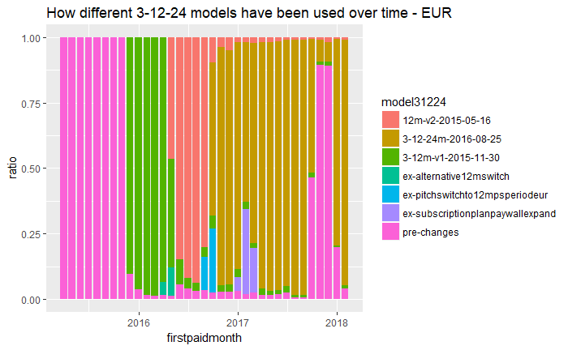

```r
tmp <- subscriptions %>%
  # Look at subs following first 1 month subs
  dplyr::filter(num_previous_subs == 1 & status != 'churn' & currency == "EUR") %>%
  # Only freemium
  dplyr::filter(isfreemium == 1) %>%
  dplyr::group_by(firstpaidmonth, model31224) %>%
  dplyr::summarise(numsubs = n()) %>%
  dplyr::group_by(firstpaidmonth) %>%
  dplyr::mutate(ratio = numsubs / sum(numsubs)) %>%
  dplyr::ungroup()
tmp %>% ggplot(aes(x=firstpaidmonth, y=ratio, fill=model31224)) + geom_col() +
  ggtitle("How different 3-12-24 models have been used over time - EUR")
```

# Three to one

Primarily for reasons of decreasing the “charge-back rate”, or in short, CB, we have been migrating 3-month users to 1-month subscriptions. It 1) creates more transactions (higher denominator lowers CB fraction) and 2) the 1-month automatic renewals cause fewer CB (lower numerator lowers CB fraction). We have done this in a mix of different markets, and for different user ages over the last couple of years. Below is some insight in what to expect. In the first migrations, we were prioritizing 1), now we are more prioritizing 2). That can be clearly seen in the plot over “At what age did we start users on 3-to-1”.

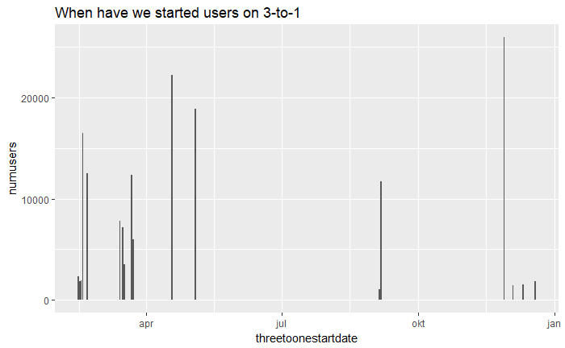

```r
tmp <- subscriptions %>%
  # aggregate on customers
  dplyr::filter(!is.na(threetoonestartdate)) %>%
  dplyr::group_by(customerid, threetoonestartdate) %>%
  dplyr::summarise(numusers = n()) %>%
  dplyr::ungroup() %>%
  dplyr::mutate(threetoonestartdate = parse_date_time(as.character(threetoonestartdate), "ymd"))
tmp %>% ggplot(aes(x=threetoonestartdate, y=numusers)) + geom_col() +
  ggtitle("When have we started users on 3-to-1")
```

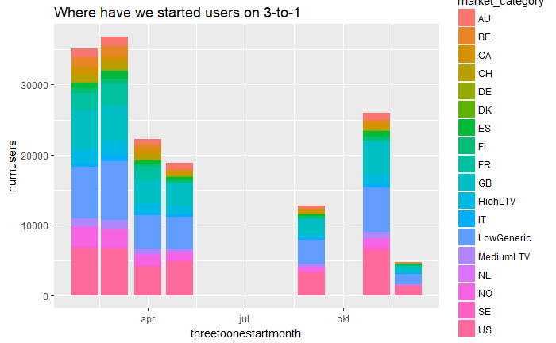

```r
tmp <- subscriptions %>%
  # aggregate on customers
  dplyr::filter(!is.na(threetoonestartdate)) %>%
  dplyr::mutate(threetoonestartmonth = floor_date(parse_date_time(as.character(threetoonestartdate), "ymd"), "month")) %>%
  dplyr::mutate(market_category = factor(market_category)) %>%
  dplyr::group_by(customerid, threetoonestartmonth, market_category) %>%
  dplyr::summarise(numusers = n()) %>%
  dplyr::ungroup()
tmp %>% ggplot(aes(x=threetoonestartmonth, y=numusers, fill = market_category)) + geom_col() +
  ggtitle("Where have we started users on 3-to-1")
```

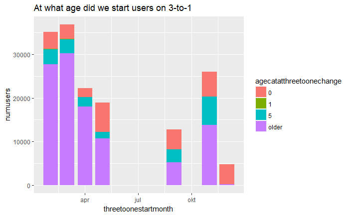

```r
intervals <- c(-1, 0, 1, 2, 3, 10, 1000)
tmp <- subscriptions %>%
  # aggregate on customers
  dplyr::filter(!is.na(threetoonestartdate)) %>%
  dplyr::mutate(threetoonestartdate = parse_date_time(as.character(threetoonestartdate), "ymd")) %>%
  dplyr::mutate(threetoonestartagemonths = interval(firstpaiddate, threetoonestartdate) %/% months(1)) %>%
  dplyr::mutate(threetoonestartmonth = floor_date(parse_date_time(as.character(threetoonestartdate), "ymd"), "month")) %>%
  dplyr::group_by(customerid, threetoonestartmonth, threetoonestartagemonths) %>%
  dplyr::summarise(numusers = n()) %>%
  dplyr::ungroup() %>%
  dplyr::mutate(agecatatthreetoonechange = ifelse(threetoonestartagemonths == 0, 0,
                                ifelse(threetoonestartagemonths <= 1, 1,
                                       ifelse(threetoonestartagemonths <= 5, 5, 'older'))))
tmp %>% ggplot(aes(x=threetoonestartmonth, y=numusers, fill = agecatatthreetoonechange)) + geom_col() +
  ggtitle("At what age did we start users on 3-to-1")
```

*paymentperiodchosenatstart* is really the *current* understanding of how we renew customers and can thus change over time for a given user. If a three-month user changes to yearly payment schedule, *paymentperiodchosenatstart* gets overwritten from 3 to 12 when this happens. It is thus only a good proxy for the first choice of periodicity of a given user, as it normally does not change a lot.

But in the 3-1 in particular, it IS changed for a lot os users and therefore, particularly with the 3-1 users, we should exercise some caution in interpreting and using *paymentperiodchosenatstart*.

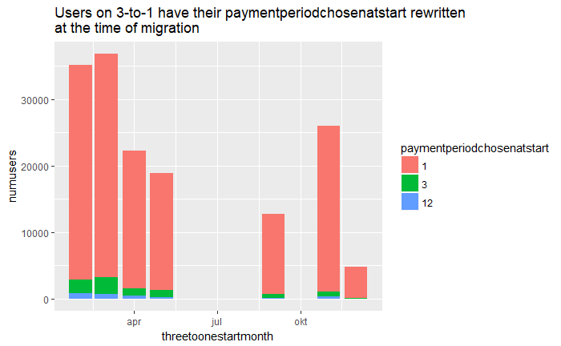

```r
tmp <- subscriptions %>%
  # aggregate on customers
  dplyr::filter(!is.na(threetoonestartdate)) %>%
  dplyr::mutate(threetoonestartmonth = floor_date(parse_date_time(as.character(threetoonestartdate), "ymd"), "month")) %>%
  dplyr::mutate(paymentperiodchosenatstart = factor(paymentperiodchosenatstart)) %>%
  dplyr::group_by(threetoonestartmonth, paymentperiodchosenatstart) %>%
  dplyr::summarise(numusers = n()) %>%
  dplyr::ungroup()
tmp %>% ggplot(aes(x=threetoonestartmonth, y=numusers, fill = paymentperiodchosenatstart)) + geom_col() +
  ggtitle("Users on 3-to-1 have their paymentperiodchosenatstart rewritten \nat the time of migration")
```

# prices

To be done